# Simple Linear Regression II

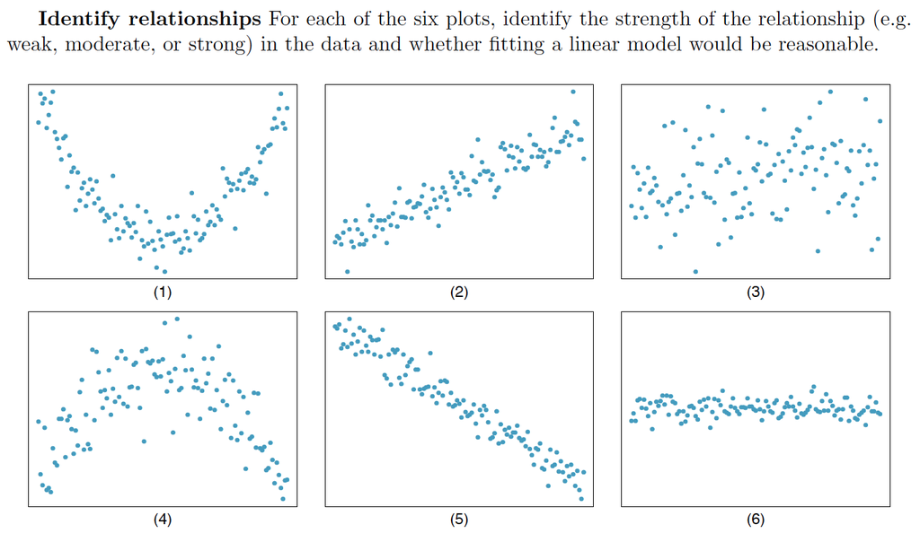

## Estimating \(\beta_1\)

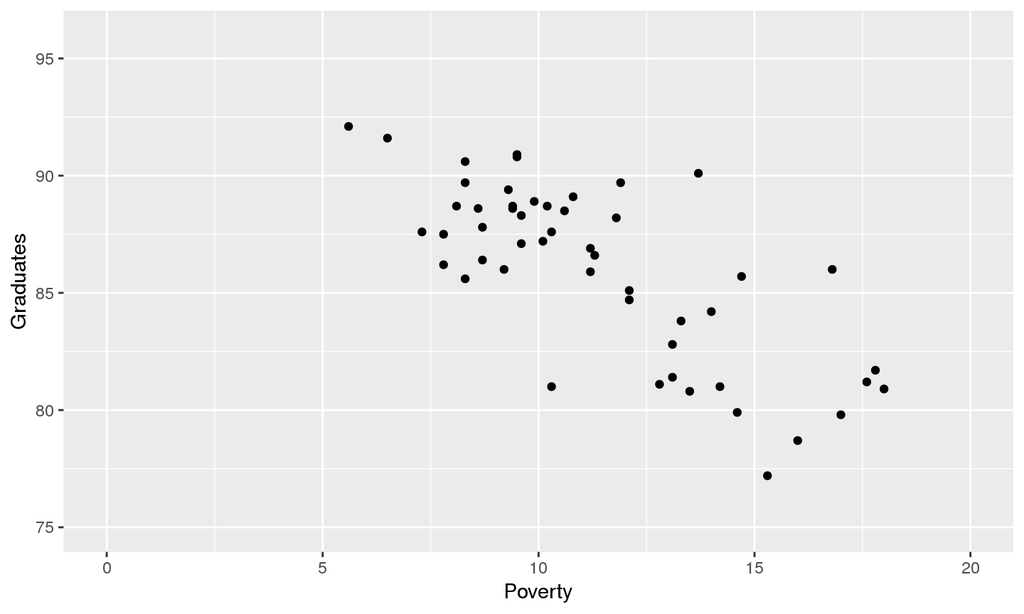

We use \(s_x, s_y, \textrm{ and } R\) to calculate \(b_1\).

## Estimating \(\beta_1\)

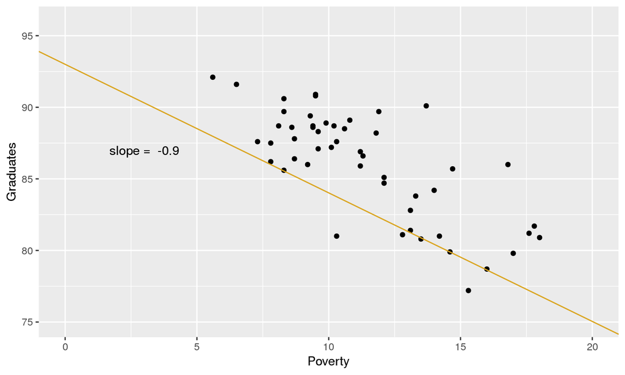

We use \(s_x, s_y, \textrm{ and } R\) to calculate \(b_1\).

## Estimating \(\beta_0\)

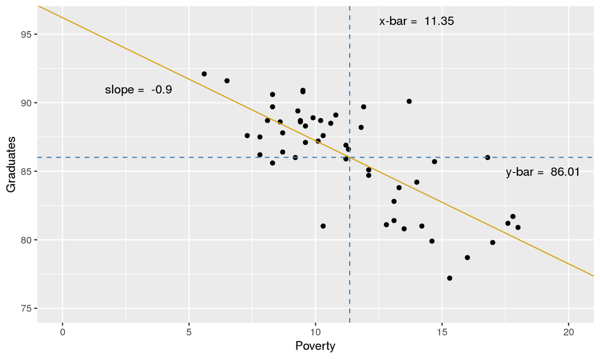

If the line of best fit *must* pass through \((\bar{x}, \bar{y})\), what is \(b_0\)?

## Estimating \(\beta_0\)

Since \((11.35, 86.01)\) is on the line, the following relationship holds.

\[ 86.01 = b_0 - 0.9 (11.35) \]

Then just solve for \(b_0\).

\[ b_0 = 86.01 + 0.9 (11.35) = 96.22\]

More generally:

\[ b_0 = \bar{y} - b_1 \bar{x} \]

## Estimation in R

```r
m1 <- lm(Graduates ~ Poverty, data = poverty)
summary(m1)
```

```
##
## Call:
## lm(formula = Graduates ~ Poverty, data = poverty)
##
## Residuals:
##    Min     1Q Median     3Q    Max
## -5.954 -1.820  0.544  1.515  6.199
##
## Coefficients:
##             Estimate Std. Error t value Pr(>|t|)
## (Intercept)   96.202      1.343   71.65  < 2e-16 ***
## Poverty       -0.898      0.114   -7.86  3.1e-10 ***
## ---
## Signif. codes:  0 '***' 0.001 '**' 0.01 '*' 0.05 '.' 0.1 ' ' 1
##
## Residual standard error: 2.5 on 49 degrees of freedom
## Multiple R-squared:  0.558,  Adjusted R-squared:  0.549
## F-statistic: 61.8 on 1 and 49 DF,  p-value: 3.11e-10
```

## The `lm` object

```r
attributes(m1)
```

```
## $names
##  [1] "coefficients"  "residuals"     "effects"       "rank"
##  [5] "fitted.values" "assign"        "qr"            "df.residual"
##  [9] "xlevels"       "call"          "terms"         "model"
##
## $class
## [1] "lm"
```

```r
m1$coef
```

```
## (Intercept)     Poverty
##      96.202      -0.898
```

```r
m1$fit
```

```
##    1    2    3    4    5    6    7    8    9   10   11   12   13   14   15
## 83.1 88.7 84.3 80.0 84.7 87.8 89.2 88.9 81.1 85.3 85.3 86.7 85.6 86.1 88.4
##   16   17   18   19   20   21   22   23   24   25   26   27   28   29   30
## 88.7 87.8 84.4 80.9 86.1 89.6 87.6 87.0 90.4 80.4 87.6 83.9 87.7 88.7 91.2
##   31   32   33   34   35   36   37   38   39   40   41   42   43   44   45
## 89.2 80.2 83.6 84.4 85.5 87.1 83.0 86.1 87.9 87.0 84.1 87.0 83.5 82.5 87.9
##   46   47   48   49   50   51
## 87.3 88.4 86.5 81.8 88.5 87.7
```

## Interpretation of \(b_1\)

The **slope** describes the estimated difference in the \(y\) variable if the explanatory variable \(x\) for a case happened to be one unit larger.

```r
m1$coef[2]
```

```
## Poverty
##  -0.898
```

*For each additional percentage point of people living below the poverty level, we expect a state to have a proprotion of high school graduates that is 0.898 lower*.

**Be Cautious**: if it is observational data, you do not have evidence of a *causal link*, but of an association, which still can be used for prediction.

## Interpretation of \(b_0\)

The **intercept** is the estimated \(y\) value that will be taken by a case with an \(x\) value of zero.

```r
m1$coef[1]
```

```
## (Intercept)
##        96.2
```

While necessary for prediction, the intercept often has no meaningful interpretation.

## Visualizing the Residuals

## Residual plot

```r
m1 <- lm(runs ~ at_bats, data = mlb11)
ggplot(m1, aes(x = .fitted, y = .resid)) +
  geom_point() +
  geom_hline(yintercept = 0, linetype = "dashed") +
  xlab("Fitted values") +
  ylab("Residuals")
```

## Residual plot

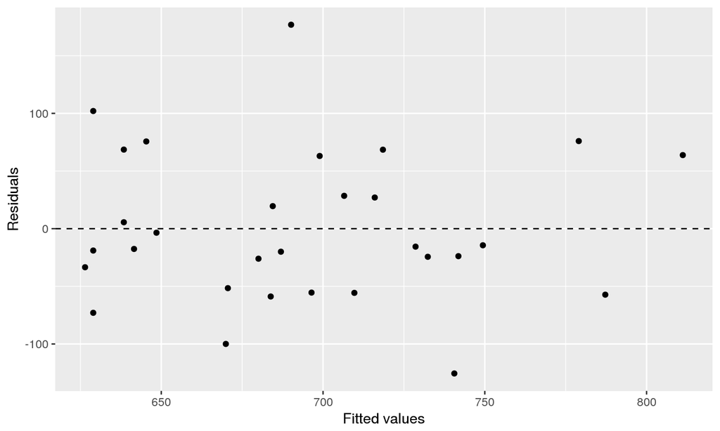

## Distribution of the residuals

```r
ggplot(m1, aes(x = .resid)) +
  geom_histogram(binwidth = 25) +
  xlab("Residuals")

ggplot(m1, aes(sample = .resid)) +
  geom_point(stat = "qq")
```

## Distribution of the residuals

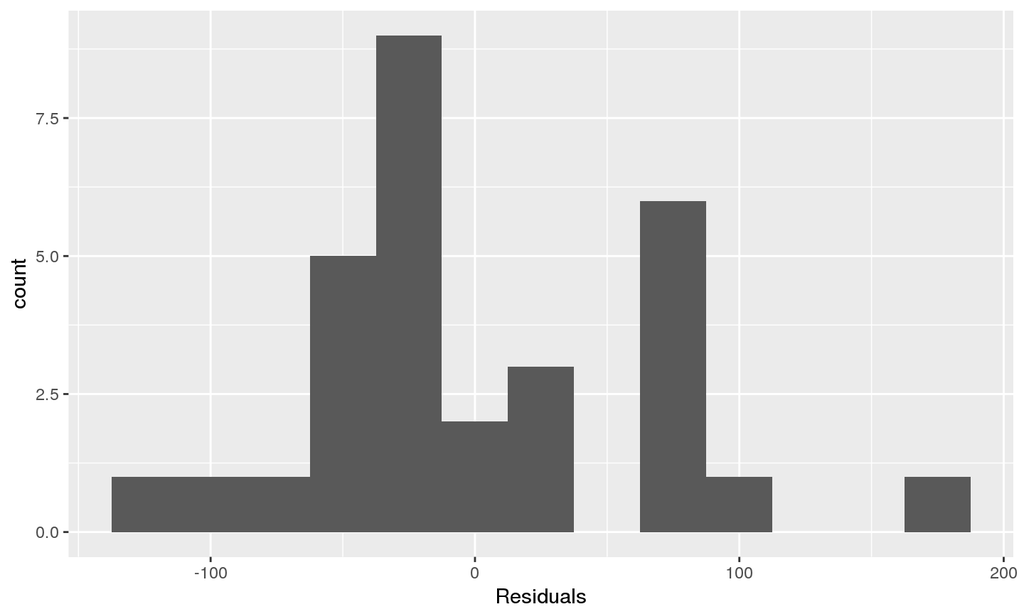

## QQ plot

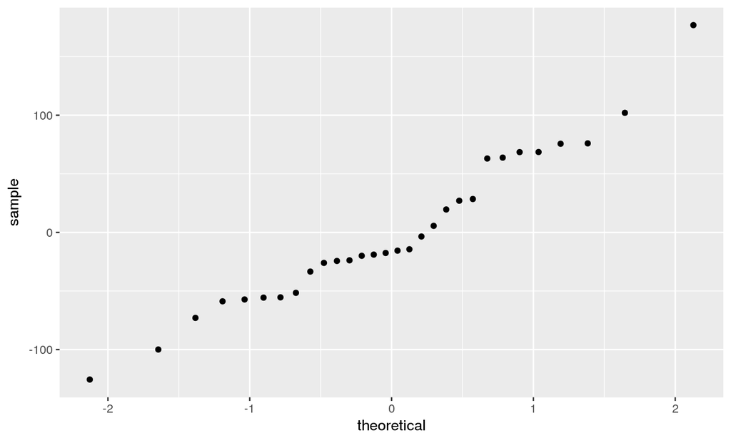